# The Grammar of Graphics: Designing and Transforming Data

Sandhya Kambhampati & Christine Zhang  
April 8, 2016

### Follow along

http://bit.ly/ggplot2workshop

### What is R?

“R is a language and environment for statistical computing and graphics”

Source: R-project.org

### What is ggplot2?

- *ggplot2* is a data visualization package for R
  - developed by Hadley Wickham
  - inspired by Leland Wilkinson's “The Grammar of Graphics”
  - provides an organizing philosophy for building graphs – a structured approach to graphing

> “The emphasis in *ggplot2* is reducing the amount of thinking time by making it easier to go from the plot in your brain to the plot on the page.”

> Wickham, 2012

### The philosophy of ggplot2

- A *ggplot2* graph is built up from a few basic elements:
  - **Data**: the raw data you want to plot
  - **Aesthetics**: including **Mapping** e.g., which variable is on the x-axis? the y-axis? Should the color/size/position of the plotted data that be mapped to some variable?
  - **Geometries**: the geometric shapes that represent the data
  - **Statistics**: statistical transformations that are used to summarize the data

Source: [Hopper (2014)](http://tomhopper.me/2014/03/28/a-simple-introduction-to-the-graphing-philosophy-of-ggplot2/)

### How to install ggplot2

```r
install.packages('ggplot2')
library('ggplot2')
```

Make sure you have the most recent version of R to get the most recent version of *ggplot2*

### The Data: US States

```r
data(state)
states.data <- as.data.frame(state.x77)
states.data$states <- rownames(states.data)
colnames(states.data)[4] <- "Life.Exp"
```

|  | Population | Income | Illiteracy | Life.Exp | Murder | HS Grad | states |
| --- | --- | --- | --- | --- | --- | --- | --- |
| Alabama | 3615 | 3624 | 2.1 | 69.05 | 15.1 | 41.3 | Alabama |
| Alaska | 365 | 6315 | 1.5 | 69.31 | 11.3 | 66.7 | Alaska |
| Arizona | 2212 | 4530 | 1.8 | 70.55 | 7.8 | 58.1 | Arizona |
| Arkansas | 2110 | 3378 | 1.9 | 70.66 | 10.1 | 39.9 | Arkansas |
| California | 21198 | 5114 | 1.1 | 71.71 | 10.3 | 62.6 | California |
| Colorado | 2541 | 4884 | 0.7 | 72.06 | 6.8 | 63.9 | Colorado |

### The Data: US States

- **Population**: population estimate as of July 1, 1975
- **Income**: per capita income (1974)
- **Illiteracy**: illiteracy (1970, percent of population)
- **Life Exp**: life expectancy in years (1969–71)
- **Murder**: murder and non-negligent manslaughter rate per 100,000 population (1976)
- **HS Grad**: percent high-school graduates (1970)  
  Source: US Census Bureau via [R datasets](https://stat.ethz.ch/R-manual/R-devel/library/datasets/html/state.html)

### How to plot your data: quick plot

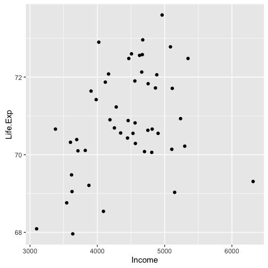

```r
qplot(Income, Life.Exp, data = states.data)
```

### How to plot your data: quick plot

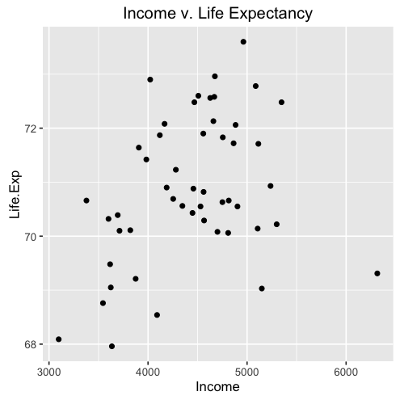

```r
qplot(Income, Life.Exp, data = states.data, main = "Income v. Life Expectancy")
```

### Basic Features of ggplot2

- Scatter Plot
- Line Graph
- Bar Graph

### Scatter Plot

```r
ggplot(data = states.data,
       aes(x = Income,
           y = Life.Exp)) +
  geom_point() +
  ggtitle("Income v. Life Expectancy")
```

### Scatter Plot

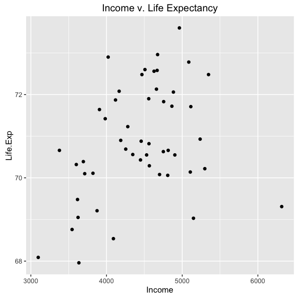

### Scatter Plot - start x-axis at 1000

```r
ggplot(data = states.data,
       aes(x = Income,
           y = Life.Exp)) +
  geom_point() +
  scale_x_continuous(limits = c(1000, 7000))
```

### Scatter Plot - start x-axis at 1000

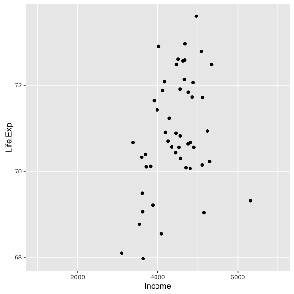

### Scatter Plot - start x-axis at 1000 (breaks every 1000), y-axis at 60

```r
ggplot(data = states.data,
       aes(x = Income,
           y = Life.Exp)) +
  geom_point() +
  scale_x_continuous(limits = c(1000, 7000),
                     breaks = seq(1000, 7000, 1000)) +
  scale_y_continuous(limits = c(60, 75))
```

### Scatter Plot - start x-axis at 1000 (breaks every 1000), y-axis at 60

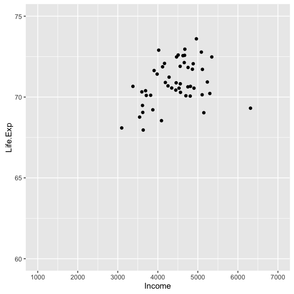

### Scatter Plot - color mapped to state

```r
ggplot(data = states.data,
       aes(x = Income,
           y = Life.Exp,
           color = states)) +
  geom_point()
```

### Scatter Plot - color mapped to state

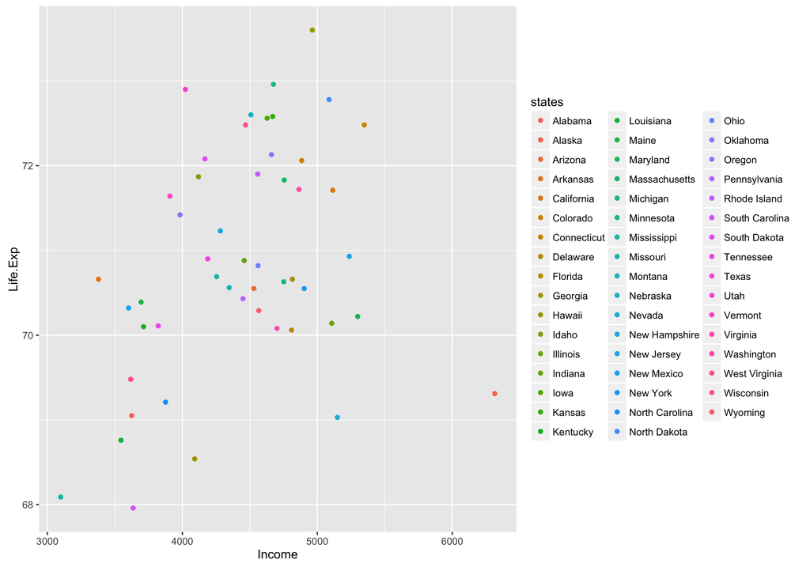

### Line Graph

```r
ggplot(data = states.data,
       aes(x = Income,
           y = Life.Exp)) +
  geom_point() +
  geom_line()
```

### Line Graph

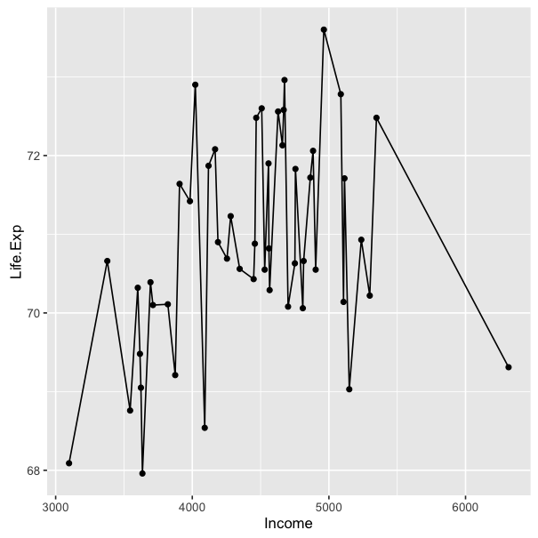

### Line Graph - specific color/size

```r
ggplot(data = states.data,
       aes(x = Income,
           y = Life.Exp)) +
  geom_point(color = 'red', size = 5) +
  geom_line(color = 'blue')
```

### Line Graph - specific color/size

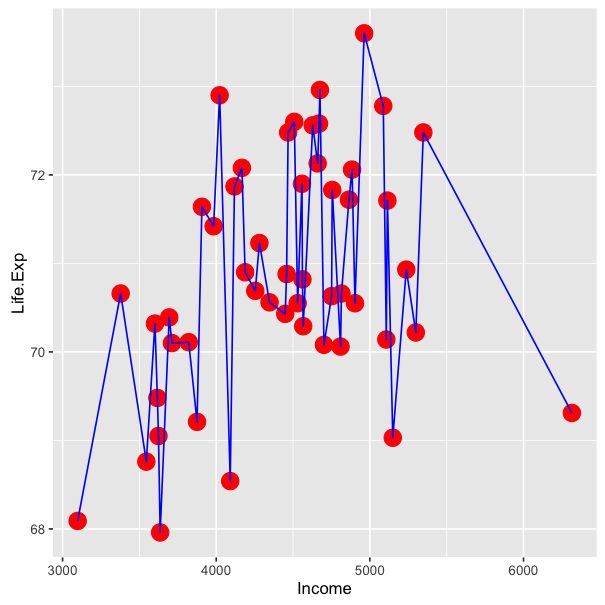

### Line Graph - points on top, different line type & point shape

```r
ggplot(data = states.data,
       aes(x = Income,
           y = Life.Exp) +
  geom_line(color = 'blue',
            linetype = 'dashed') +
  geom_point(color = 'red',
             size = 2,
             shape = 15)
```

### Line Graph - points on top, different line type & point shape

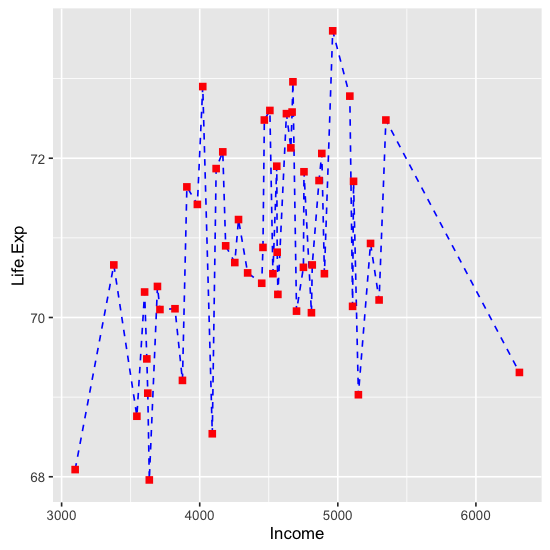

### Bar Graph - simple

```r
three.states <- states.data[states.data$states == "California" | states.data$states == "New York" | states.data$states == "Texas", ]
```

- We picked three states from the data: California, New York, and Texas

|  | Population | Income | Illiteracy | Life.Exp | Murder | HS Grad | states |
| --- | --- | --- | --- | --- | --- | --- | --- |
| California | 21198 | 5114 | 1.1 | 71.71 | 10.3 | 62.6 | California |
| New York | 18076 | 4903 | 1.4 | 70.55 | 10.9 | 52.7 | New York |
| Texas | 12237 | 4188 | 2.2 | 70.90 | 12.2 | 47.4 | Texas |

### Bar Graph - simple

```r
ggplot(data = three.states,
       aes(x = states,
           y = Population)) +
  geom_bar(stat = 'identity')
```

### Bar Graph - simple

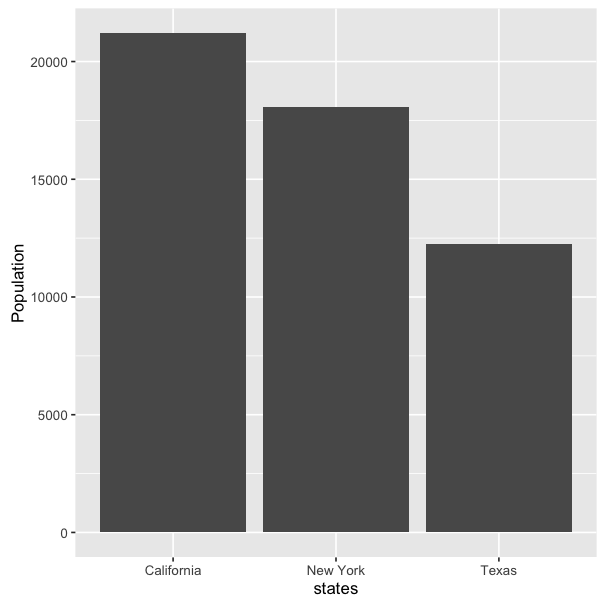

### Bar Graph - simple, transparent background

```r
ggplot(data = three.states,
       aes(x = states,
           y = Population)) +
  geom_bar(stat = 'identity') +
  theme(panel.background = element_blank())
```

### Bar Graph - transparent background

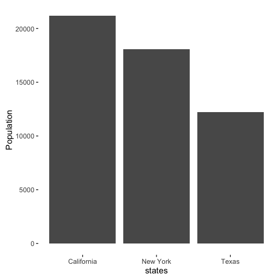

### Bar Graph - stacked

```r
three.states$Category <- ifelse(three.states$states == "Texas", "Texas", "California/New York")
```

- We created a variable, *Category*, that places the data into two categories: “Texas” if it's from Texas, and “California/New York” if it's from California or New York

|  | Population | Income | Illiteracy | Life.Exp | Category |
| --- | --- | --- | --- | --- | --- |
| California | 21198 | 5114 | 1.1 | 71.71 | California/New York |
| New York | 18076 | 4903 | 1.4 | 70.55 | California/New York |
| Texas | 12237 | 4188 | 2.2 | 70.90 | Texas |

### Bar Graph - stacked

```r
ggplot(data = three.states,
       aes(x = Category,
           fill = states)) +
  geom_bar(position = 'stack') +
  theme(panel.background = element_blank())
```

### Bar Graph - stacked

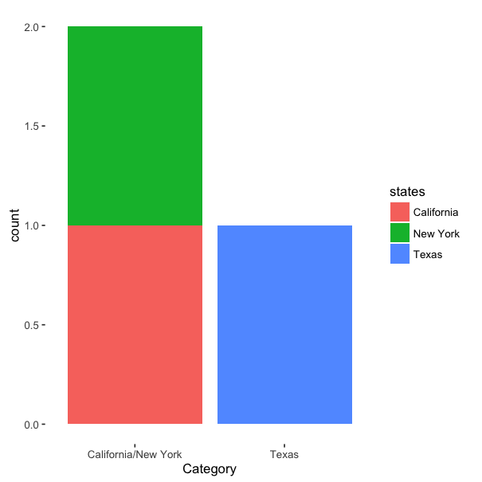

### Bar Graph - stacked

```r
ggplot(data = three.states,
       aes(x = Category,
           y = Illiteracy,
           fill = states)) +
  geom_bar(stat = 'identity',
           position = 'stack') +
  theme(panel.background = element_blank())
```

### Bar Graph - stacked

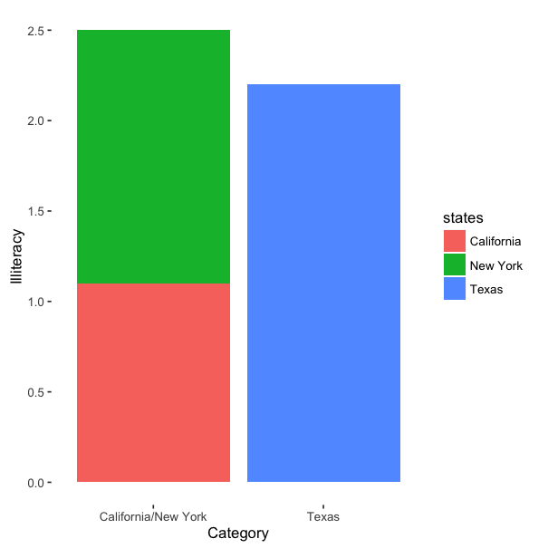

### Advanced Features

- Facetting
- Fitted Lines
- Text Labels

### Facetting

- Facetting allows you to split up your data by one or two variables
- *facet_grid()* places one or two variables in either vertical or horizontal directions
- *facet_wrap()* places facets next to each other, wrapping with a certain # of rows and/or columns

```
facet_grid(vertical ~ horizontal)

facet_wrap(~ variable, nrow = ___, ncol = ___)
```

### Facetting

```r
states.data$Pop.Under.2000 <- ifelse(states.data$Population < 2000, "Pop Under 2000", "Pop Above 2000")
```

- We created a variable, *Pop.Under.2000*, which shows whether the population (in thousands) is under 2000 or above 2000

### Facetting

```r
ggplot(data = states.data,
       aes(x = Income,
           y = Life.Exp)) +
  geom_point() +
  facet_grid(. ~ Pop.Under.2000)
```

### Facetting

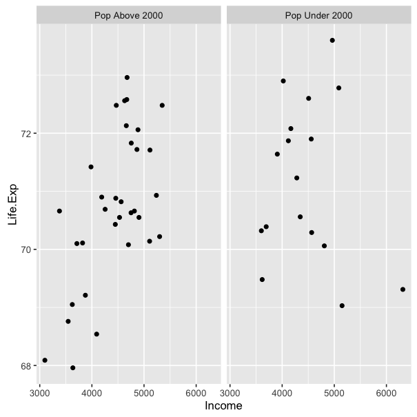

### Fitted Lines

- How do we draw a fitted line through these points?

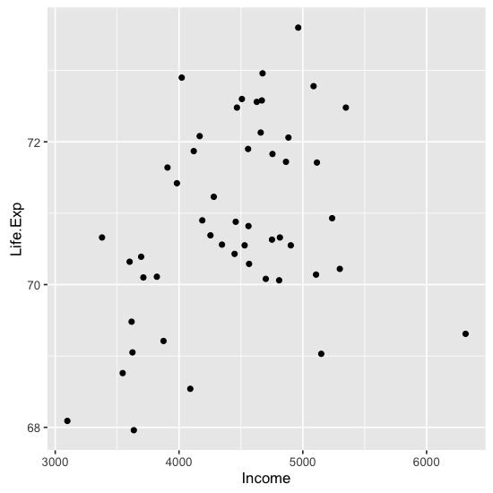

### Fitted Lines

```r
ggplot(data = states.data,
       aes(x = Income,
           y = Life.Exp)) +
  geom_point() +
  stat_smooth()
```

### Fitted Lines

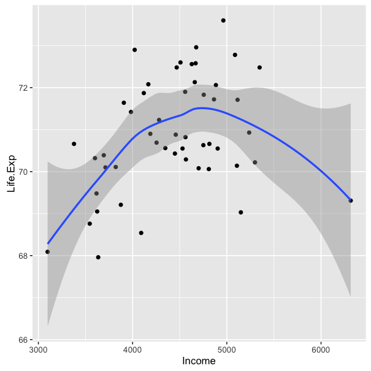

### Fitted Lines

```r
ggplot(data = states.data,
       aes(x = Income,
           y = Life.Exp)) +
  geom_point() +
  stat_smooth(method = 'lm')
```

### Fitted Lines

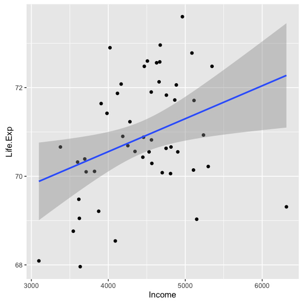

### Text Labels

```r
ggplot(data = states.data,
       aes(x = Income,
           y = Life.Exp)) +
        geom_text(aes(label = states))
```

### Text Labels

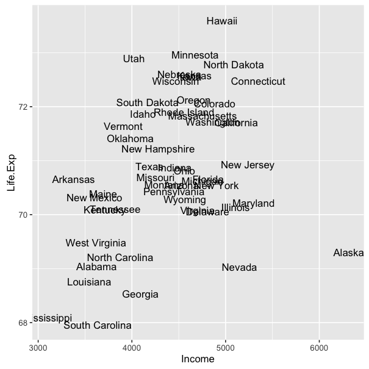

### The philosophy of ggplot2 - recap

- A *ggplot2* graph is built up from a few basic elements:
  - **Data**: the raw data you want to plot
  - **Aesthetics**: including **Mapping** e.g., which variable is on the x-axis? the y-axis? Should the color/size/position of the plotted data that be mapped to some variable?
  - **Geometries**: the geometric shapes that represent the data
  - **Statistics**: statistical transformations that are used to summarize the data

Source: [Hopper (2014)](http://tomhopper.me/2014/03/28/a-simple-introduction-to-the-graphing-philosophy-of-ggplot2/)

### Resources

- [“A Layered Grammar of Graphics”](http://vita.had.co.nz/papers/layered-grammar.html) by Hadley Wickham
- [“A Simple Introduction to the Graphing Philosophy of ggplot2”](http://tomhopper.me/2014/03/28/a-simple-introduction-to-the-graphing-philosophy-of-ggplot2/) by Tom Hopper
- [ggplot2 Cheat Sheet](https://www.rstudio.com/wp-content/uploads/2015/03/ggplot2-cheatsheet.pdf) by RStudio
- [ggplot2 Documentation](http://docs.ggplot2.org/current/) by Hadley Wickham & Winston Chang
- [Resources for Doing Data Journalism](http://rddj.info/) by Timo Grossenbacher
- [Shapes and Line Types in R](http://www.cookbook-r.com/Graphs/Shapes_and_line_types/) by Winston Chang

### Thank You + Questions

http://bit.ly/ggplot2workshop

Sandhya Kambhampati  
[@sandhya__k](https://twitter.com/sandhya__k)

Christine Zhang  
[@christinezhang](https://twitter.com/christinezhang)